# Homework 11

Solutions will be available after Monday, November 9, 2026.

## Question 1: Implementing K-means

K-means is a relatively simple algorithm that we can write ourselves. For Questions 1 and 2, do not use an existing function that performs K-means directly.

Generate 10 observations with two independent standard normal coordinates. Set a random seed and report it. Randomly assign the observations to $K=2$ clusters, making sure neither cluster is empty. Let $C(i)$ denote the cluster assigned to observation $x_i$, and let $m_k$ denote the mean of cluster $k$.

1. Perform one iteration: calculate the cluster means, then assign each observation to its closest mean using Euclidean distance. Report the means and updated assignments, and plot the observations colored by their updated assignments.

```
Seed: 121

Cluster means:
 Cluster  Initial mean x1  Initial mean x2  Updated mean x1  Updated mean x2
       1           0.9672          -0.2561           1.2820          -0.2217
       2           0.1180          -0.2984          -0.8762          -0.3666

Observation assignments:
 Observation           (x1, x2)  Original C(i)  Updated C(i)
           1 (-0.2445, -0.5780)              2             2
           2  (0.2599, -1.0764)              2             2
           3   (1.4689, 0.5916)              2             1
           4  (0.9672, -0.2561)              1             1
           5  (2.3699, -0.3700)              2             1
           6  (-0.5876, 0.7849)              2             2
           7 (-1.5827, -0.8693)              2             2
           8  (0.6872, -0.9441)              2             1
           9 (-2.2262, -0.0944)              2             2
          10  (0.9170, -0.1298)              2             1
```

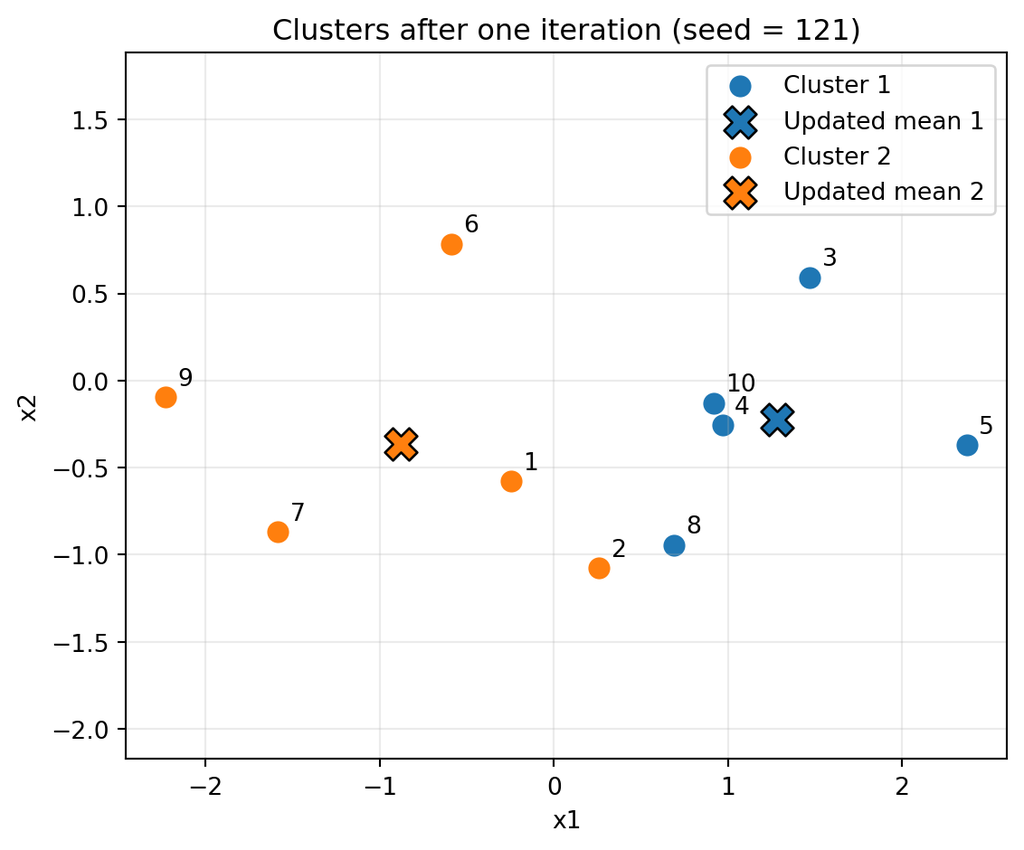

```python
import numpy as np
import pandas as pd
import matplotlib.pyplot as plt

seed = 121
rng = np.random.default_rng(seed)
X = rng.standard_normal((10, 2))
K = 2
original = rng.integers(1, K + 1, size=len(X))
while len(np.unique(original)) < K:
    original = rng.integers(1, K + 1, size=len(X))

initial_means = np.vstack([X[original == k].mean(axis=0)
                           for k in range(1, K + 1)])
distances = np.linalg.norm(X[:, None, :] - initial_means[None, :, :], axis=2)
updated = distances.argmin(axis=1) + 1
updated_means = np.vstack([X[updated == k].mean(axis=0)
                           for k in range(1, K + 1)])

mean_table = pd.DataFrame({
    "Cluster": np.arange(1, K + 1),
    "Initial mean x1": initial_means[:, 0],
    "Initial mean x2": initial_means[:, 1],
    "Updated mean x1": updated_means[:, 0],
    "Updated mean x2": updated_means[:, 1],
})
assignment_table = pd.DataFrame({
    "Observation": np.arange(1, len(X) + 1),
    "(x1, x2)": [f"({x1:.4f}, {x2:.4f})" for x1, x2 in X],
    "Original C(i)": original,
    "Updated C(i)": updated,
})
print(f"Seed: {seed}")
print("\nCluster means:")
print(mean_table.round(4).to_string(index=False))
print("\nObservation assignments:")
print(assignment_table.to_string(index=False))

fig, ax = plt.subplots(figsize=(6, 5))
for k, color in zip(range(1, K + 1), ["tab:blue", "tab:orange"]):
    points = X[updated == k]
    ax.scatter(points[:, 0], points[:, 1], color=color, label=f"Cluster {k}", s=65)
    ax.scatter(*updated_means[k - 1], color=color, marker="X", s=180,
               edgecolors="black", label=f"Updated mean {k}")
for i, (x1, x2) in enumerate(X, start=1):
    ax.annotate(str(i), (x1, x2), xytext=(5, 5), textcoords="offset points")
ax.set(xlabel="x1", ylabel="x2", title="Clusters after one iteration (seed = 121)")
ax.set_aspect("equal", adjustable="datalim")
ax.legend()
ax.grid(alpha=0.25)
fig.tight_layout()
plt.show()
```

2. Write a function that repeats these two steps until the assignments stop changing or a specified maximum number of iterations is reached. Your function should work for a data matrix with any number of variables and a chosen number of clusters $K$. Start from a nonempty assignment to each cluster; if a cluster becomes empty during iteration, keep its previous mean. Recalculate the cluster means from the final assignments before returning them. Return the final assignments, cluster means, and within-cluster sum of squares,

   $$\sum_{k=1}^K\sum_{i:\,C(i)=k}\lVert x_i-m_k\rVert^2.$$

```python
def kmeans_manual(X, K, initial, max_iter=100):
    X = np.asarray(X, dtype=float)
    labels = np.array(initial, copy=True)
    if X.ndim != 2 or 0 in X.shape or not np.isfinite(X).all():
        raise ValueError("X must be a nonempty matrix of finite numbers.")
    if not isinstance(K, (int, np.integer)) or not 1 <= K <= len(X):
        raise ValueError("K must be an integer between 1 and the number of observations.")
    if labels.shape != (len(X),) or not np.array_equal(
        np.unique(labels), np.arange(1, K + 1)
    ):
        raise ValueError("initial must assign each observation to 1,...,K with no empty clusters.")
    if not isinstance(max_iter, (int, np.integer)) or max_iter < 1:
        raise ValueError("max_iter must be a positive integer.")

    means = np.vstack([X[labels == k].mean(axis=0) for k in range(1, K + 1)])
    for iteration in range(1, max_iter + 1):
        distances = np.linalg.norm(X[:, None, :] - means[None, :, :], axis=2)
        updated_labels = distances.argmin(axis=1) + 1
        converged = np.array_equal(updated_labels, labels)
        labels = updated_labels
        for k in range(1, K + 1):
            if np.any(labels == k):
                means[k - 1] = X[labels == k].mean(axis=0)
        if converged:
            break

    wcss = np.sum((X - means[labels - 1]) ** 2)
    return {"assignments": labels, "means": means, "wcss": float(wcss),
            "iterations": iteration, "converged": converged}

fit_1b = kmeans_manual(X, K, original)
print(f"Converged: {fit_1b['converged']}; iterations: {fit_1b['iterations']}")
print("Final assignments:", fit_1b["assignments"])
print("Final cluster means:")
print(pd.DataFrame(fit_1b["means"], columns=["x1", "x2"],
                   index=pd.Index(range(1, K + 1), name="Cluster")).round(4))
print(f"Within-cluster sum of squares: {fit_1b['wcss']:.4f}")
```

```
Converged: True; iterations: 3
Final assignments: [2 1 1 1 1 2 2 1 2 1]
Final cluster means:
             x1      x2
Cluster
1        1.1117 -0.3642
2       -1.1603 -0.1892
Within-cluster sum of squares: 8.5518
```

3. Apply your function to the same 10 observations from two different random initial assignments. Report the final plots, cluster means, and within-cluster sums of squares. Do the two runs produce the same grouping and objective value? Explain your findings.

```
Run summary:
 Run  Initial assignment seed  Iterations  Converged   WCSS
   1                      121           3       True 8.5518
   2                      122           2       True 8.5518

Final cluster means:
 Run  Cluster  Mean x1  Mean x2
   1        1   1.1117  -0.3642
   1        2  -1.1603  -0.1892
   2        1  -1.1603  -0.1892
   2        2   1.1117  -0.3642

Initial and final assignments:
 Observation  Run 1 initial  Run 1 final  Run 2 initial  Run 2 final
           1              1            2              2            1
           2              2            1              2            2
           3              1            1              1            2
           4              1            1              1            2
           5              1            1              2            2
           6              2            2              1            1
           7              2            2              1            1
           8              2            1              1            2
           9              1            2              1            1
          10              2            1              2            2

Same grouping (allowing relabeled clusters): True
Same within-cluster sum of squares: True
```

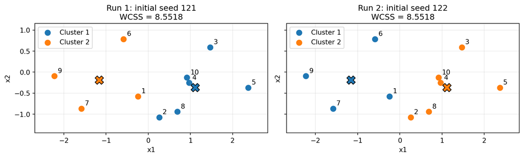

```python
initial_seeds = [121, 122]
starts_1c = []
fits_1c = []
for start_seed in initial_seeds:
    start_rng = np.random.default_rng(start_seed)
    start = start_rng.integers(1, K + 1, size=len(X))
    while len(np.unique(start)) < K:
        start = start_rng.integers(1, K + 1, size=len(X))
    starts_1c.append(start)
    fits_1c.append(kmeans_manual(X, K, start))

summary_1c = pd.DataFrame({
    "Run": [1, 2],
    "Initial assignment seed": initial_seeds,
    "Iterations": [fit["iterations"] for fit in fits_1c],
    "Converged": [fit["converged"] for fit in fits_1c],
    "WCSS": [fit["wcss"] for fit in fits_1c],
})
mean_rows_1c = [(run, k, *fit["means"][k - 1])
                for run, fit in enumerate(fits_1c, start=1)
                for k in range(1, K + 1)]
means_1c = pd.DataFrame(mean_rows_1c,
                       columns=["Run", "Cluster", "Mean x1", "Mean x2"])
assignments_1c = pd.DataFrame({"Observation": np.arange(1, len(X) + 1)})
for run, (start, fit) in enumerate(zip(starts_1c, fits_1c), start=1):
    assignments_1c[f"Run {run} initial"] = start
    assignments_1c[f"Run {run} final"] = fit["assignments"]

labels1, labels2 = [fit["assignments"] for fit in fits_1c]
same_grouping = np.array_equal(labels1[:, None] == labels1[None, :],
                               labels2[:, None] == labels2[None, :])
same_wcss = np.isclose(fits_1c[0]["wcss"], fits_1c[1]["wcss"])
print("Run summary:")
print(summary_1c.round(4).to_string(index=False))
print("\nFinal cluster means:")
print(means_1c.round(4).to_string(index=False))
print("\nInitial and final assignments:")
print(assignments_1c.to_string(index=False))
print(f"\nSame grouping (allowing relabeled clusters): {same_grouping}")
print(f"Same within-cluster sum of squares: {same_wcss}")

fig, axes = plt.subplots(1, 2, figsize=(11, 4.5), sharex=True, sharey=True)
for run, (fit, ax) in enumerate(zip(fits_1c, axes), start=1):
    for k, color in zip(range(1, K + 1), ["tab:blue", "tab:orange"]):
        points = X[fit["assignments"] == k]
        ax.scatter(points[:, 0], points[:, 1], color=color, s=65,
                   label=f"Cluster {k}")
        ax.scatter(*fit["means"][k - 1], color=color, marker="X", s=160,
                   edgecolors="black")
    for i, (x1, x2) in enumerate(X, start=1):
        ax.annotate(str(i), (x1, x2), xytext=(5, 5), textcoords="offset points")
    ax.set(xlabel="x1", ylabel="x2",
           title=f"Run {run}: initial seed {initial_seeds[run - 1]}\nWCSS = {fit['wcss']:.4f}")
    ax.margins(x=0.10, y=0.20)
    ax.set_aspect("equal", adjustable="box")
    ax.legend()
    ax.grid(alpha=0.25)
fig.tight_layout()
plt.show()
```

Both runs produce the groups $\{2,3,4,5,8,10\}$ and $\{1,6,7,9\}$, with cluster labels swapped between runs. The corresponding means are $(1.1117,-0.3642)$ and $(-1.1603,-0.1892)$, and both within-cluster sums of squares equal **8.5518**. Run 1 converges in 3 iterations and run 2 in 2 iterations. These two different initial assignments reach the same solution.

## Question 2: Image color compression

Pick your favorite color image and use your K-means function from Question 1 to cluster its pixels. For computational efficiency, resize the image to no more than $200\times200$ pixels and use its three RGB color channels.

1. Plot the original image and report its dimensions. Transform it into a data matrix with one observation per pixel and three variables: red, green, and blue. Report the dimensions of this matrix.

```
Source photograph (width x height): 4672 x 7008
Resized image (width x height): 200 x 200
RGB array dimensions (height, width, channels): (200, 200, 3)
Pixel data matrix dimensions (observations, RGB variables): (40000, 3)
RGB scale: 0–1; columns: red, green, blue
```

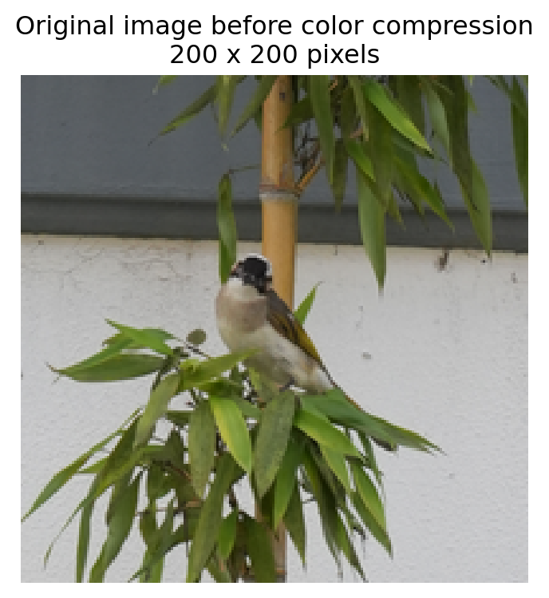

```python
from pathlib import Path
from PIL import Image, ImageOps

image_path = Path("ori.JPG")
if not image_path.exists():
    image_path = Path("homework/week-11/ori.JPG")
with Image.open(image_path) as source:
    source_image = ImageOps.exif_transpose(source).convert("RGB")

crop_box = (1925, 3255, 3125, 4455)
image_2a = source_image.crop(crop_box).resize((200, 200), Image.Resampling.LANCZOS)
image_2a.save(image_path.with_name("bird-200.png"))
rgb_2a = np.asarray(image_2a, dtype=float) / 255.0
pixels_2a = rgb_2a.reshape(-1, 3)

print(f"Source photograph (width x height): {source_image.width} x {source_image.height}")
print(f"Resized image (width x height): {image_2a.width} x {image_2a.height}")
print(f"RGB array dimensions (height, width, channels): {rgb_2a.shape}")
print(f"Pixel data matrix dimensions (observations, RGB variables): {pixels_2a.shape}")
print("RGB scale: 0–1; columns: red, green, blue")

fig, ax = plt.subplots(figsize=(4, 4))
ax.imshow(rgb_2a, interpolation="nearest")
ax.set_title("Original image before color compression\n200 x 200 pixels")
ax.axis("off")
fig.tight_layout()
plt.show()
```

2. For $K=2,3,5,10$, apply your function to the pixel data. Report the cluster means and within-cluster sum of squares for each $K$. Reconstruct and plot each compressed image by replacing every pixel with its assigned cluster mean. Use the same RGB scale for all fits.

```
Random initialization seed: 121

Fit summary (RGB scale: 0–1):
 K     WCSS  Iterations  Converged
 2 928.3377           5       True
 3 529.7643          49       True
 5 285.8778          31       True
10 115.9228         201       True

Cluster means (RGB scale: 0–1):
 K  Cluster    Red  Green   Blue
 2        1 0.7366 0.7352 0.7247
 2        2 0.3308 0.3498 0.2302
 3        1 0.2582 0.2819 0.1436
 3        2 0.7424 0.7417 0.7345
```

[output cut: 16 more lines]

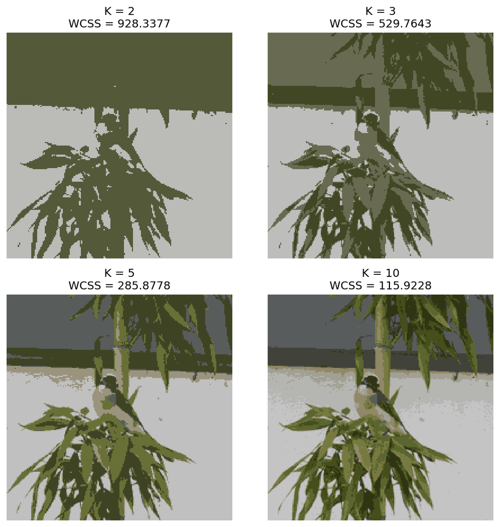

```python
seed_2b = 121
rng_2b = np.random.default_rng(seed_2b)
cluster_counts_2b = [2, 3, 5, 10]
fits_2b = {}
compressed_2b = {}
mean_rows_2b = []

for n_clusters in cluster_counts_2b:
    initial_2b = rng_2b.integers(1, n_clusters + 1, size=len(pixels_2a))
    while len(np.unique(initial_2b)) < n_clusters:
        initial_2b = rng_2b.integers(1, n_clusters + 1, size=len(pixels_2a))
    fit = kmeans_manual(pixels_2a, n_clusters, initial_2b, max_iter=1000)
    fits_2b[n_clusters] = fit
    compressed_2b[n_clusters] = fit["means"][fit["assignments"] - 1].reshape(rgb_2a.shape)
    mean_rows_2b.extend((n_clusters, cluster, *mean)
                        for cluster, mean in enumerate(fit["means"], start=1))

summary_2b = pd.DataFrame([
    {"K": n_clusters, "WCSS": fit["wcss"],
     "Iterations": fit["iterations"], "Converged": fit["converged"]}
    for n_clusters, fit in fits_2b.items()
])
means_2b = pd.DataFrame(mean_rows_2b,
                       columns=["K", "Cluster", "Red", "Green", "Blue"])
print(f"Random initialization seed: {seed_2b}")
print("\nFit summary (RGB scale: 0–1):")
print(summary_2b.round(4).to_string(index=False))
print("\nCluster means (RGB scale: 0–1):")
print(means_2b.round(4).to_string(index=False))

fig, axes = plt.subplots(2, 2, figsize=(8, 8))
for ax, n_clusters in zip(axes.flat, cluster_counts_2b):
    ax.imshow(compressed_2b[n_clusters], interpolation="nearest")
    ax.set_title(f"K = {n_clusters}\nWCSS = {fits_2b[n_clusters]['wcss']:.4f}")
    ax.axis("off")
fig.tight_layout()
plt.show()
```

3. Which value of $K$ would you choose for this image? Briefly justify your choice using the reconstructed images and the within-cluster sums of squares. I would choose 5. The image with k = 5 is similar to image with k = 10, and the marginal deduction in within-cluster sums of squares is relatively small.

## Question 3: Hierarchical clustering of cars

The file `data/mtcars.csv` contains 11 numerical variables for 32 cars, including fuel economy, horsepower, and weight. The `car` column gives the model names; use it to label observations, not as a clustering variable. You may use existing hierarchical clustering functions for this question.

1. Standardize each numerical variable to have mean 0 and standard deviation 1. Using Euclidean distance, perform hierarchical clustering with single, complete, and average linkage. Plot the three dendrograms with the car names and compare the results.

```
Clustering data: 32 cars x 11 variables

Standardization check:
      Mean  Sample SD
mpg   -0.0        1.0
cyl   -0.0        1.0
disp   0.0        1.0
hp     0.0        1.0
drat  -0.0        1.0
wt    -0.0        1.0
qsec  -0.0        1.0
vs     0.0        1.0
am     0.0        1.0
gear  -0.0        1.0
carb   0.0        1.0
```

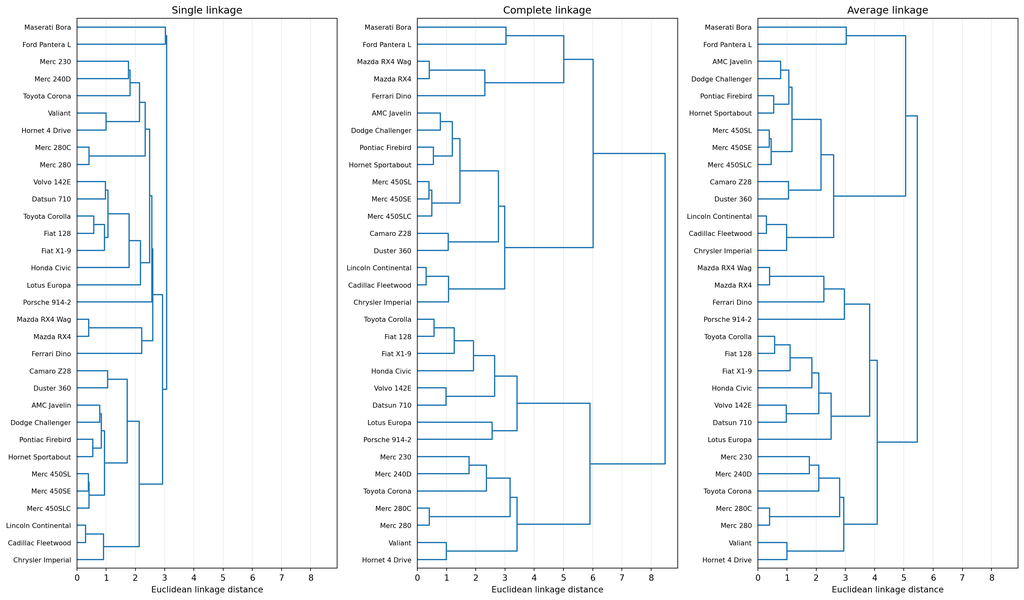

```python
from pathlib import Path
from scipy.spatial.distance import pdist
from scipy.cluster.hierarchy import linkage, dendrogram

car_path = Path("data/mtcars.csv")
if not car_path.exists():
    car_path = Path("homework/week-11/data/mtcars.csv")
cars_3a = pd.read_csv(car_path).set_index("car")
scaled_cars_3a = (cars_3a - cars_3a.mean()) / cars_3a.std(ddof=1)
distances_3a = pdist(scaled_cars_3a.to_numpy(), metric="euclidean")
trees_3a = {}

print(f"Clustering data: {scaled_cars_3a.shape[0]} cars x {scaled_cars_3a.shape[1]} variables")
print("\nStandardization check:")
print(pd.DataFrame({"Mean": scaled_cars_3a.mean(),
                    "Sample SD": scaled_cars_3a.std(ddof=1)}).round(6).to_string())

fig, axes = plt.subplots(1, 3, figsize=(17, 10), sharex=True)
for ax, method in zip(axes, ["single", "complete", "average"]):
    trees_3a[method] = linkage(distances_3a, method=method)
    dendrogram(trees_3a[method], labels=cars_3a.index.tolist(),
               orientation="right", leaf_font_size=8, ax=ax,
               color_threshold=0, above_threshold_color="tab:blue")
    ax.set_title(f"{method.capitalize()} linkage")
    ax.set_xlabel("Euclidean linkage distance")
    ax.grid(axis="x", alpha=0.25)
axes[0].set_xlim(0, 1.05 * max(tree[-1, 2] for tree in trees_3a.values()))
fig.tight_layout()
plt.show()
```

Single linkage has smallest distance at the end, and complete linkage has biggest distance at the end. The overall group is similart over three linkage methods.

2. Choose one linkage method and a number of clusters that you consider reasonable. Report the cluster memberships and a table of cluster means on the original variable scales. Describe the main characteristics of the groups and explain your choice using the dendrogram and table. Briefly explain why standardizing the variables matters for this analysis.

```python
from scipy.cluster.hierarchy import fcluster

groups_3b = fcluster(trees_3a["complete"], t=4, criterion="maxclust")
means_3b = cars_3a.groupby(groups_3b).mean()
mean_table_3b = means_3b.T
mean_table_3b.columns = [f"Cluster {cluster}" for cluster in means_3b.index]
mean_table_3b.index.name = "Variable"
mean_table_3b.round(3)
```

| Variable | Cluster 1 | Cluster 2 | Cluster 3 | Cluster 4 |
| --- | --- | --- | --- | --- |
| mpg | 20.743 | 28.075 | 15.050 | 18.500 |
| cyl | 5.143 | 4.000 | 8.000 | 6.800 |
| disp | 175.114 | 93.612 | 357.617 | 223.400 |
| hp | 102.143 | 81.875 | 194.167 | 198.800 |
| drat | 3.570 | 4.184 | 3.121 | 3.836 |
| wt | 3.194 | 2.042 | 4.104 | 3.001 |
| qsec | 19.967 | 18.450 | 17.143 | 15.616 |
| vs | 1.000 | 0.875 | 0.000 | 0.000 |
| am | 0.000 | 1.000 | 0.000 | 1.000 |
| gear | 3.571 | 4.250 | 3.000 | 4.600 |
| carb | 2.143 | 1.500 | 3.083 | 5.200 |

The following table lists the cars in each cluster.

```python
membership_table_3b = pd.DataFrame({
    f"Cluster {cluster}": pd.Series(cars_3a.index[groups_3b == cluster].tolist())
    for cluster in means_3b.index
}).fillna("")
membership_table_3b.index = np.arange(1, len(membership_table_3b) + 1)
membership_table_3b.index.name = "Member"
membership_table_3b
```

| Member | Cluster 1 | Cluster 2 | Cluster 3 | Cluster 4 |
| --- | --- | --- | --- | --- |
| 1 | Hornet 4 Drive | Datsun 710 | Hornet Sportabout | Mazda RX4 |
| 2 | Valiant | Fiat 128 | Duster 360 | Mazda RX4 Wag |
| 3 | Merc 240D | Honda Civic | Merc 450SE | Ford Pantera L |
| 4 | Merc 230 | Toyota Corolla | Merc 450SL | Ferrari Dino |
| 5 | Merc 280 | Fiat X1-9 | Merc 450SLC | Maserati Bora |
| 6 | Merc 280C | Porsche 914-2 | Cadillac Fleetwood |  |
| 7 | Toyota Corona | Lotus Europa | Lincoln Continental |  |
| 8 |  | Volvo 142E | Chrysler Imperial |  |
| 9 |  |  | Dodge Challenger |  |
| 10 |  |  | AMC Javelin |  |
| 11 |  |  | Camaro Z28 |  |
| 12 |  |  | Pontiac Firebird |  |

There is difference in average for each cluster. Standardizing making the difference between two observation on different variables comparable.